# Лекция 11. Она же и тест.

# Распознавание речи

Основы математического аппарата спектрального, кепстрального анализа и скрытых цепей Маркова уже были ранее рассмотрены в лекциях про Спектр, Кепстр весеннего семестра и в лекции 9 про Скрытые Марковскиее цепи этого семестра. Поэтому мы не будем их подробно рассматривать. Здесь мы рассмотрим только применение к задаче распознавания речи. Эта не единственная схема распознавания речи, однако, спектр и кепстр используется в большинстве из них. Обычно `features` именно из кепстра и используют для обучения соответствующих нейронных сетей и случайных лесов распознавания речи. Хорошие результаты распознавания также дают классическме методы классификации из Лекции 8 этого семестра. Большая часть кода уже написана и приводится ниже. Вам остается дописать недостающие части кода и правильно скомпоновать компоненты кода для тренировки модели распознавания и непосредственно распознавания содержания предлагаемых звуковых файлов. Автором идеи лекции и соответствующего задания является мой давний друг и соавтор (знакомы и вместе работаем с 1982 года) профессор университета Чикаго,США Баласанов Ю.Г. В США студенты выполняют это задание за одну неделю, но готового кода им выдается больше, чем здесь.

## Тренировка модели распознавания

В папке MNIST_9-25 находятся подпапки num0,num1,...,num9 c звуковыми файлами цифр 0,1,...,9 соответственно, на английском языке, которые Вы будете использовать для тренировки модели распознавания. Файлы записывались сотрудниками лаборатории статистического анализа ВМК МГУ, знакомыми американцами и членам их семей, правда среди них были также китайцы и русские, так что некоторый акцент в произношении неизбежен. Из них было смоделировано случайным образом варианты из 300 телефонных номеров по 10 цифр каждый, цифры которого произносятся разными случайными спикерами. Обход всех тренировочных файлов выполняется с помощью следующего кода. В качестве примера, ниже приведен пример кода обхода только 5 файлов из каждой папки. Попутно разбираем имя каждой папки, запоминая номер цифры label, для которой будет строится модель в текущей папке. В функции build_one_model будет непосредственно и обучается модель для каждой цифры в отдельности. Но о параметрах функции `num_cepstr` и `num_states`, а также непосредственно об тренировке модели позднее, пока добавим в ее название tmp и она в качестве примера только выводит имена первых 5 файлов.

В приведенном в лекции коде не указаны необходимые пакеты, надеюсь разберетесь самостоятельно и все пакеты установите. Далее идет образец кода прохода по всем цифрам кода с тренировочными данными и вызовом функции `build_one_model_tmp` - имитации построения модели для одной цифры. О том, что в `build_one_model_tmp` необходимо изменить см. ниже.

```python
import os

def build_one_model_tmp(input_folder, num_states, num_cep_coeff):
    # input_folder: path to the folder containing training wav files with the word
    # num_states: number of hidden states in HMM
    # num_cep_coeff: number of MFCC features extracted from each time window
    training_files = [x for x in os.listdir(input_folder) if x.endswith('.wav')]
    file_num = 0
    for filename in training_files:
        file_num += 1
        # Extract the current filepath and read the file
        filepath = os.path.join(input_folder, filename)
        print(filename)
        if file_num == 5:
            return
    return

input_folder = "./MNIST_9-25"
num_components = 15
num_cepstr = 17
for dirname in os.listdir(input_folder):
    # Get name of subfolder
    subfolder = os.path.join(input_folder, dirname)
    print("folder=",subfolder)
    if not os.path.isdir(subfolder):
        continue

        # Extract label
    label = subfolder[subfolder.rfind('/') + 1:]
    build_one_model_tmp(subfolder, num_states=num_components, num_cep_coeff=num_cepstr)
```

```
folder= ./MNIST_9-25\num0
0_phone_0.wav
10_phone_0.wav
11_phone_0.wav
12_phone_0.wav
13_phone_0.wav
folder= ./MNIST_9-25\num1
0_phone_1.wav
100_phone_1.wav
101_phone_1.wav
102_phone_1.wav
103_phone_1.wav
folder= ./MNIST_9-25\num2
0_phone_2.wav
10_phone_2.wav
11_phone_2.wav
12_phone_2.wav
13_phone_2.wav
folder= ./MNIST_9-25\num3
0_phone_3.wav
100_phone_3.wav
101_phone_3.wav
102_phone_3.wav
103_phone_3.wav
folder= ./MNIST_9-25\num4
0_phone_4.wav
100_phone_4.wav
101_phone_4.wav
102_phone_4.wav
103_phone_4.wav
folder= ./MNIST_9-25\num5
0_phone_5.wav
100_phone_5.wav
101_phone_5.wav
102_phone_5.wav
103_phone_5.wav
folder= ./MNIST_9-25\num6
0_phone_6.wav
10_phone_6.wav
11_phone_6.wav
12_phone_6.wav
13_phone_6.wav
folder= ./MNIST_9-25\num7
0_phone_7.wav
100_phone_7.wav
101_phone_7.wav
102_phone_7.wav
103_phone_7.wav
folder= ./MNIST_9-25\num8
0_phone_8.wav
100_phone_8.wav
101_phone_8.wav
10_phone_8.wav
11_phone_8.wav
folder= ./MNIST_9-25\num9
0_phone_9.wav
100_phone_9.wav
10_phone_9.wav
11_phone_9.wav
12_phone_9.wav
```

Обратите внимание что файлы выдаются не упорядоченны по номерам. Это не важно при тренировке модели, но очень важно при получении Вашего окончательного результата. Об этом я дополнительно сообщу.

Главную роль в нашей модели распознавания будет играть следующий класс из пакета `hmmlearn`.

```python
from hmmlearn import hmm
class ModelHMM(object):
    def __init__(self, num_components=8, num_iter=1000):
        self.n_components = num_components
        self.n_iter = num_iter
    # Define the covariance type and the type of HMM:
        self.cov_type = 'diag'
        self.model_name = 'GaussianHMM'
    # Initialize the variable in which we will store the models for each word:
        self.models = []
    # Define the model using the specified parameters:
        self.model = hmm.GaussianHMM(n_components=self.n_components,
                covariance_type=self.cov_type,n_iter=self.n_iter)

    # Define a method to train the model
    # 'training_data' is a 2D numpy array where each row has length of number of mfcc coefficients
    def train(self, training_data):
        np.seterr(all='ignore')
        cur_model = self.model.fit(training_data)
        self.models.append(cur_model)

    # Define a method to compute log likelihood score for input features
    def compute_score(self, input_data):
        return self.model.score(input_data)  # model.score returns log likelihood of sample input_data
```

Приведенный выше класс задает параметры нашей модели скрытых Марковских цепей - количество состояний цепи Маркова, максимального числа итераций при оценке цепи Маркова и вызывает методы для оценки параметоров цепи и вычисления логарифма функции правдоподобия для распознавания. Для его работы понадобится класс `hmm` из пакета `hmmlearn`

### Подготовка features для обучения модели

Будем добавлять в функцию `build_one_model` код для построения `features`

```python
def build_one_model(input_folder, num_states, num_cep_coeff):
    # input_folder: path to the folder containing training wav files with the word
    # num_states: number of hidden states in HMM
    # num_cep_coeff: number of MFCC features extracted from each time window
    X = np.array([])  # features
    training_files = [x for x in os.listdir(input_folder) if x.endswith('.wav')]
    for filename in training_files:
        # Extract the current filepath and read the file
        filepath = os.path.join(input_folder, filename)
        sampling_freq, signal = wavfile.read(filepath)
        sound = AudioSegment.from_file(filepath, format="wav")
        duration = len(sound)

        start_trim = detect_leading_silence(sound)
        end_trim = detect_leading_silence(sound.reverse())
        duration = len(sound)
        trimmed_sound = sound[start_trim:duration - end_trim]
        trimmed_sound.export("tmp.wav", format="wav")
        # Extract features
        # Default values:
        # winlen=0.025, winstep=0.01, nfft=512,
        with warnings.catch_warnings():
            warnings.simplefilter('ignore')
            features_mfcc = mfcc(signal, sampling_freq, numcep=num_cep_coeff)

        # Append features to the variable X
        if len(X) == 0:
            X = features_mfcc
        else:
            X = np.append(X, features_mfcc, axis=0)

    # Initiate HMM model object
    with warnings.catch_warnings():
        warnings.filterwarnings('ignore', category=DeprecationWarning)
        model = ModelHMM(num_components=num_states)

    # Train HMM model, calculate likelihood of the sample by the trained model
    with warnings.catch_warnings():
        warnings.filterwarnings('ignore', category=DeprecationWarning)
        model.train(X)
        model_score = model.compute_score(X)

    return model, model_score, num_cep_coeff
```

Здесь используется функция `detect_leading_silence`, которая определяет длительность шума перед сигналом, она же определяет длительность шума после сигнала. Код функции можно выполнить так

```python
def detect_leading_silence(sound, silence_threshold=-50.0, chunk_size=10):
    '''
    sound is a pydub.AudioSegment
    silence_threshold in dB
    chunk_size in ms

    iterate over chunks until you find the first one with sound
    '''
    trim_ms = 0 # ms

    assert chunk_size > 0 # to avoid infinite loop
    while sound[trim_ms:trim_ms+chunk_size].dBFS < silence_threshold and trim_ms < len(sound):
        trim_ms += chunk_size

    return trim_ms
```

В начале функции создадим пустой массив X - numpy массив для сбора `features` для каждого файла. Затем читаем текущий файл с записью цифры. Определяем длительность паузы перед сигналом цифры и паузу в конце сигнала цифры оператором `trimmed_sound = sound[start_trim:duration - end_trim]` выделяем непосредственно сигнал. **Внимание!!! Некоторые сигналы могут получиться очень короткие (меньше скажем 150 милисекунд) или вообще пустые, тогда их следует пропустить. В коде этого нет, вставите код проверки сами.**

Далее вызывается функция

features_mfcc = mfcc(signal, sampling_freq, numcep=num_cep_coeff)

Параметры по умолчанию которой winlen=0.025, winstep=0.01, nfft=512 Это соответственно ширина окна в секундах, размер сдвига окна в секундах и количество частот для построения спектра мощности для текущего окна. Так как использется алгоритм быстрого преобразования Фурье последнее число должно быть степенью двойки.

Параметр `numcep` - это число кепстральных коэффициентов, которое вычисляется для каждого положения окна внутри сигнала. Вспомнить, что делает эта функция поможет шайни https://shiny.ilykei.com/ANDoynikov/cepstrum/ , которую Вы уже видели в весеннем семестре.

Далее `features_mmfc` добавляются в массив X После обхода всех файлов с текущей цифрой создается класс `ModelHMM`

model = ModelHMM(num_components=num_states)

где `num_states` - чмсло состояний скрытой цепи Маркова. И происходит оценка параметров соответствующей скрытой цепи Маркова для всех полученых `features` из массива Х, также вычисляется максимальное достигнутое значение функции правдоподобия Итак, построена модель для одной текущей цифры.

Следующая функция собирает модели для всех цифр от 0 до 9 в переменную `speech_models`

```python
def build_models(input_folder):

    # input_folder contains subfolders with samples of words in wav files

    # Initialize the variable to store all the models
    speech_models = []

    # Parse the input directory
    for dirname in os.listdir(input_folder):

        # Get name of subfolder
        subfolder = os.path.join(input_folder, dirname)

        if not os.path.isdir(subfolder):
            continue

        # Extract label
        label = subfolder[subfolder.rfind('/') + 1:]

        # Fit model for label
        model = build_one_model(subfolder, num_states=num_components, num_cep_coeff=num_cepstr)

        # Add the model to the list
        speech_models.append((model, label))

        # Reset model variable
        model = None
        print("Fitted "+dirname)
    return speech_models
```

Модель следует сохранить в файл, чтобы не проводить обучение каждый раз перед использованием

```python
from sklearn.externals import joblib
joblib.dump(digit_models,'saved.pkl')
```

Возможен чуть более сложный, но перспективный способ построения модели через tensorflow tf. Сначала строим спектр audio сигнала,где fft_length степень двойки 256 или 512.

```python
    audio = tf.io.read_file(path)
    audio, _ = tf.audio.decode_wav(audio, 1)
    audio = tf.squeeze(audio, axis=-1)

    stfts = tf.signal.stft(audio, frame_length=200, frame_step=80, fft_length=fft_length)
    spectrograms = tf.abs(stfts)
```

Затем делаем преобразование Мела спектрограммы. Подробности см. здесь https://en.wikipedia.org/wiki/Mel-frequency_cepstrum

### Распознавание цифр телефона по сохраненной модели

Начнем с чтения сохраненной модели

```python
speech_models = joblib.load('saved.pkl')
```

Прочитаем один из файлов нулевого варианта и нарисуем график сигнала. На графике хорошо заметны сигналы от 10 цифр номера

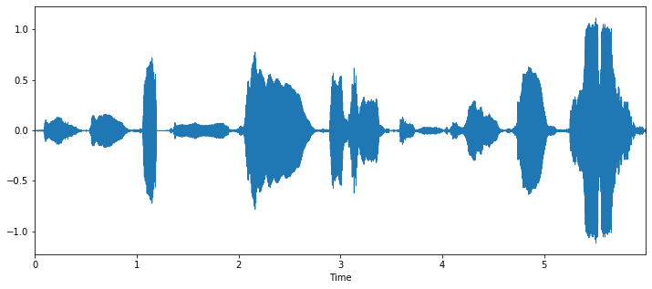

```
Signal rate=  22050
```

```python
import librosa
import librosa.display
import matplotlib.pyplot as plt
wavfile = "./test/0/1.wav"
#data, rate = sf.read(wavfile, dtype='float32')
x, sr = librosa.load(wavfile)
# Plot the sample.
plt.figure(figsize=(12, 5))
librosa.display.waveplot(x, sr=sr)
plt.show()
print("Signal rate= ",sr)
```

Это запись номера телефона из 10 цифр, записанная поцифренно разными людьми на английском языке.

Первая задача, которую Вам надо решить после построения модели это разделить его на отдельные цифры. Легче всего это делается с помощью функции `split_on_silence`.

```python
from pydub import AudioSegment
from pydub.silence import split_on_silence
sound_file = AudioSegment.from_wav(wavfile)
silence_len = 100
thresh = -40
audio_chunks = split_on_silence(sound_file, min_silence_len=silence_len, silence_thresh=thresh)
num_signals = len(audio_chunks)
print(num_signals)
```

```
9
```

Чтобы не делать это каждый раз, Вас следует самостоятельно написать код функции, которая сама определяет оптимальную длину паузы между цифрами, чтобы их получилось ровно 10.

Итак будем считать, что Вы разделили запись на 10 цифр

Следующая функция получает `features` и вычисляет логарифм функции правдоподобия, при условии, что модель этой цифры в переменной `trained_model` для каждого куска сигнала `сhanks` из набора `audio_chunks`, полученного выше. Не знаю зачем, но перед вызовом каждый `сhanks` я записал в звуковой файл `tmp.wav`. Это параметр test_file_path='tmp.wav'. Наверное можно обойтись без записи файла `tmp.wav`попробуйте написать этот код самостоятельно.

```python
def score_one_word(trained_model, test_file_path):
    # trained_model: ModelHMM object with trained model
    # test_file_path: path to wav file

    sampling_freq, signal = wavfile.read(test_file_path)
    num_cep_coeff = trained_model[2]

    # Extract features
    # Default values:
    # winlen=0.025, winstep=0.01, nfilt=26, nfft=512,
    with warnings.catch_warnings():
        warnings.simplefilter('ignore')
        features_mfcc = mfcc(signal, sampling_freq, numcep=num_cep_coeff)

        # Calculate log likelihood
        word_score = trained_model[0].compute_score(features_mfcc)
    return word_score
```

Значение логарифма правдоподобия `word_score` идет на выход этой функции. Эта функция в свою очередь вызывается в цикле по моделям всех цифр от 0 до 9. Выбирается та цифра, где логарифм функции правдоподобия максимальный. Это переменная `predicted_label`

```python
max_score = -float('inf')
        # Run the current feature vector through all the HMM
        #  models and pick the one with the highest score
for item in speech_models:
    model, label = item
    ....
    predicted_label = label #label which has highest score
```

Итак, одна цифра из 10 цифр телефона угадана. Указанная схема повторяется для всех `сhanks` из набора `audio_chunks`. Код для этого напишите напишите самостоятельно.

В результате мы получим полностью номер телефона. Например, '0123439516' его надо сохранить в массив номеров телефонов. Лучше хранить его как строку, а не число, в противном случае, если первый 0 в номере, то он пропадет и весь номер телефон при проверке окажется не правильным.

Мы готовы определить все произнесенные 300 номеров телефона. Из полученных номеров телефонов создается массив, который сохраняется в файл результатов в формате. Имя столбца не указывается.

0,3459986127

1,2335530968

2,9540596584

3,2871961713

......

298,9341169408

299,7697136246

Первый столбец это номер звукового файла в его названии, например файл называется `11.wav` означает, что в первом столбце стоит 11. Второй столбец (после запятой) собственно номер телефона. **Внимание!!! В следующем ниже цикле по всем звуковым файлам. Файлы выбираются не упорядоченные 0-ой, 1-й, 2-й и так далее, а в некотором другом порядке.**

```python
for filename in test_files:
    print('\nFile=' + filename)
```

За этим следует проследить, так как проверка производится (извините за неудобство) именно в упорядоченном виде 0-ой, 1-й, 2-й файл и так далее до 299-го. В противном случае, можно получить в результате 0 баллов, хотя и все номера определены верно. Затем вызвать тестовое приложение по ссылке https://shiny.ilykei.com/ANDoynikov/Test416/Test11 и загрузить в него полученный Вами файл. В результате смотрите полученную `confusion matrix` и `accuracy`, которая и будет Вашим числом набранных баллов. Запоминается только лучший результат, который можно увидеть внизу окна с результатами.

**Указание!!! Используйте для тренировки нулевой вариант, ответы которого будут даны. Попробуйте также обучить модель при разных значениях параметров `num_cepstr` и `num_states`. Обычно их берут от 10 до 30 каждый, причем больше не означает лучше**

*В качестве отчета обязательно высылать по почте файл с Вашим кодом и файл с ответом с именем например ans_10.csv- ответ 10 варианта . Буду обязательно проверять на плагиат. А Вашему ответу буду получать баллы. Именно это число баллов будет стоять в результатах.*